# Examen Parcial

Investigación y Análisis de Datos II

Mayo 8, 2017

### Solución

Cierta fiesta de fin de semestre reúne a 57 personas, de las cuales 31 saben bailar. Durante las primeras horas la celebración transcurre sin contratiempos, pero eventualmente los vecinos se quejan del albroto y obligan al anfitrión a controlar el ambiente. Con tal de no detener la fiesta por completo, éste elige 20 personas al azar para permanecer en la casa y corre al resto.

Entrada la noche, con los vecinos finalmente tranquilos pero con los 20 invitados restantes alarmantemente sobrios (incluso después de dar cuenta de toda la cerveza en la casa), el anfitrión decide compartir lo que le queda de una botellita de mezcal ultra-súper para enfrentar la madrugada. Como no es una botella nueva el mezcal no alcanza para todos: sólo salen 8 caballitos, cada uno con poder fumigador capaz de noquear al bailarín más resistente, que entrega a los primeros 8 invitados que se le cruzan en el camino.

Imagina que llegas a la fiesta con ganas de bailar, justo después de que el mezcal se reparte, y que empiezas a buscar bailarines. Asumiendo que nadie que haya tomado mezcal puede bailar (al margen de si sabe o no sabe), y que cualquier persona que sepa bailará contigo:

**1. Especifica la distribución conjunta entre las variables `f`, `s` y `b`, que representan: `f: número de bailarines que quedaron después de correr a los 37 desafortunados` `s: número de bailarines que no probaron el mezcal (i.e., que todavía pueden bailar)` `b: número de bailarines que puedes encontrar al preguntar a 18 personas (con remplazo)`**

*Empezamos especificando los posibles valores que cada variable aleatoria **podría** tomar, de acuerdo con la definición del problema:*

```r
rm(list=ls())

# Posibles números de bailarines que sobreviven a la primera extracción:
sup_f <- 0:20

# Elegir a 8 bailarines para darles mezcal equivale a elegir a
# 12 bailarines para no darles mezcal:
sup_s <- 0:12

# Al muestrear 18 bailarines (con reemplazo) es posible encontrar
# desde 0 (suerte muy mala) hasta 18 (suerte muy buena) bailarines:
sup_b <- 0:18
```

*Podemos especificar directamente la distribución marginal sobre `f` porque esta es la variable sobre la que tenemos más información (todos los parámetros son conocidos, asumiendo que se trata de un proceso hipergeométrico):*

```r
p_f <- dhyper(sup_f,
              m=31,
              n=57-31,
              k=20)
```

*La cantidad de bailarines que se salvan del mezcal depende de cuántos bailarines se salvaron de la primera eliminación, `f`, número que es incierto, variable, o desconocido. Aparte, también depende del número de caballitos (para cuántos bailarines **no** alcanzan). La “influencia” condicional de `f` sobre `s`, y la distribución prior sobre `f`, permiten calcular la distribución conjunta entre ambas variables:*

$$P(f,s)=P(s|f)P(f)$$

*De manera similar, la cantidad de bailarines que pueden aparecer en 18 extracciones con remplazo depende (directamente) de cuántos bailarines se salvaron del mezcal, y de cuántos bailarines se quedaron en la fiesta (indirectamente). La distribución conjunta sobre las tres variables puede calcularse empleando nuevamente la **regla de la cadena**:*

$$\begin{aligned}
P(f,s,b)&=P(b|f,s)P(f,s)\\
&=P(b|f,s)P(s|f)P(f)
\end{aligned}$$

*El código siguiente calcula la distribución conjunta sobre las tres variables. En palabras, para cada valor del soporte de `f`, para cada valor del soporte de `s` calcula la distribución conjunta entre `f` y `s` y después calcula la distribución conjunta entre todos los posibles valores de `b` y la combinación particular de `f` y `s` actual.*

```r
p_fs <- array(dim=c(length(sup_f),length(sup_s)))
p_fsb <- array(dim=c(length(sup_f),length(sup_s),length(sup_b)))

for(ff in 1:length(sup_f)){
  for(ss in 1:length(sup_s)){
    p_fs[ff,ss] <- p_f[ff]*dhyper(sup_s[ss],
                                  m=sup_f[ff],
                                  n=20-sup_f[ff],
                                  k=12)
    for(bb in 1:length(sup_b)){
      p_fsb[ff,ss,bb] <- p_fs[ff,ss]*dbinom(sup_b[bb],
                                            prob=sup_s[ss]/12,
                                            size=18)
    }
  }
}
```

**2. ¿Cuántas combinaciones diferentes incluye dicha distribución (contando combinaciones posibles e imposibles)?**

*El tamaño del espacio muestra, o bien el número total de combinaciones posibles, equivale al producto de la longitud de los soportes:*

$$(21)(13)(19)=5187$$

*Lo cual coincide con el tamaño del objeto `p_fsb`:*

```r
dim(p_fsb)
```

```
## [1] 21 13 19
```

```r
cumprod(dim(p_fsb)) # La función 'cumprod' devuelve el producto acumulado de un vector numérico. (El segundo resultado corresponde con el tamaño de la distribución conjunta entre 'f' y 's'.)
```

```
## [1]   21  273 5187
```

**3. Especifica las distribuciones marginales sobre cada variable y descríbelas. ¿Cuántas personas crees que bailarán contigo?**

*En tanto que una distribución conjunta especifica qué tan probable es observar combinaciones particulares entre dos o más variables aleatorias, es posible analizar a cada variable aleatoria por separado **marginalizando** la distribución conjunta, es decir, sumando (o integrando) a través de las variables aleatorias que no son de interés. **Si se trata de variables discretas**, las distribuciones marginales se pueden calcular de la siguiente manera:*

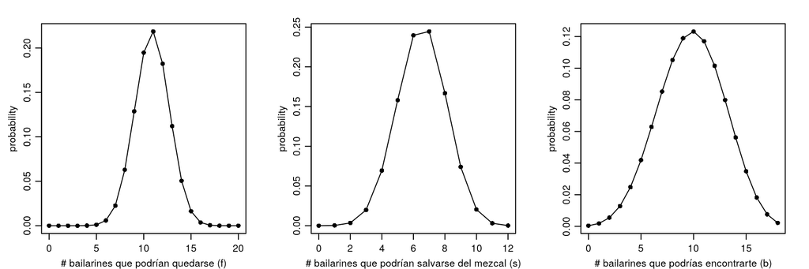

```r
p_f <- apply(p_fsb,MARGIN=1,FUN=sum,na.rm=T)
p_s <- apply(p_fsb,MARGIN=2,FUN=sum,na.rm=T)
p_b <- apply(p_fsb,MARGIN=3,FUN=sum,na.rm=T)
plot_marginal <- function(support,distribution,
                          xlabel,color='black'){
  plot(support,distribution,
       pch=16,type='o',ylab='probability',xlab=xlabel)
}
layout(matrix(1:3,ncol=3,byrow=T))
par(mgp=c(2,.75,0),mar=c(3,3.5,2,2))
plot_marginal(sup_f,p_f,'# bailarines que podrían quedarse (f)')
plot_marginal(sup_s,p_s,'# bailarines que podrían salvarse del mezcal (s)')
plot_marginal(sup_b,p_b,'# bailarines que podrías encontrarte (b)')
```

*En palabras, lo más probable es que sobrevivan entre 10 y 12 bailarines a la primera exterminación, que 6 ó 7 bailarines se salven del mezcal, y que termines bailando con entre 8 y 12 personas.*

**4. Imagina que encuentras `b=14` bailarines entre los 18 invitados a los que preguntas. ¿Cuántos bailarines crees que sobrevivieron la primera eliminación y cuántos crees que se salvaron del mezcal? Especifica la distribución conjunta posterior sobre dichas variables (`f` y `s`) y las marginales posteriores sobre cada una; compara cada distribución posterior contra la distribución prior correspondiente y presenta tus conclusiones.**

*Podemos imaginar la distribución conjunta entre estas tres variables como un cubo de 21 renglones (tamaño del soporte de `f`) por 13 columnas (soporte de `s`) por 19 posiciones de profundidad (soporte de `b`). El observar una **realización** de `b` nos indica en qué posición de profundidad nos encontramos (o bien, elimina la incertidumbre sobre la dimensión de profundidad). El saber dónde nos encontramos respecto de `b` no elimina la incertidumbre sobre las dos variables restantes, pero la modifica respecto de la incertidumbre inicial de acuerdo con el **Teorema de Bayes**:*

$$\begin{aligned}
P(f,s|b=14)&=\frac{P(b=14|f,s)P(f,s)}{P(b=14)}\\\\
&=\frac{P(b=14,f,s)}{P(b=14)}\\
\end{aligned}$$

```r
slice_b <- which(sup_b==14)
# ¿Qué tan probable es observar b=14?
print(p_b[slice_b])
```

```
## [1] 0.05623321
```

```r
# ...o bien...
print(sum(p_fsb[,,slice_b]))
```

```
## [1] 0.05623321
```

```r
# La distribución posterior sobre las dos variables no observadas...
posterior_fs_given_b14 <- p_fsb[,,slice_b]/p_b[slice_b]
# ...es una distribución de 21 por 13 posiciones...
dim(posterior_fs_given_b14)
```

```
## [1] 21 13
```

```r
sum(posterior_fs_given_b14,na.rm=T)
```

```
## [1] 1
```

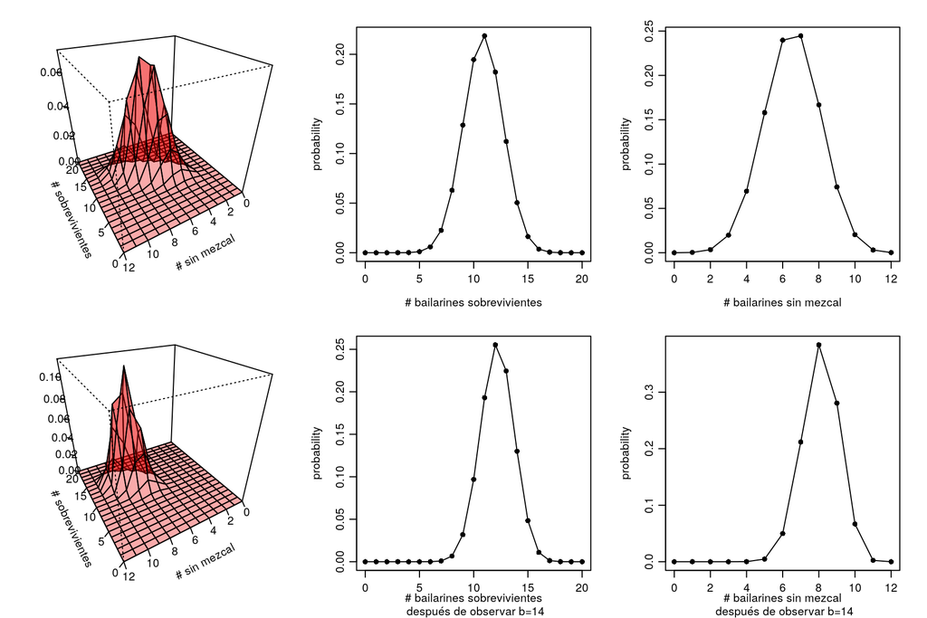

```r
# ...que nuevamente podemos marginalizar, si nos interesa llegar a conclusiones sobre cada variable por separado (lo cual, por cierto, casi nunca es recomendable):
pos_f_g_b14 <- apply(posterior_fs_given_b14,
                     MARGIN = 1,FUN = sum,na.rm=T)
pos_s_g_b14 <- apply(posterior_fs_given_b14,
                     MARGIN = 2,FUN = sum,na.rm=T)

# Gráficamente:
plot_joint_fs <- function(sup_x,sup_y,surface,color){
  persp(sup_x,sup_y,surface,
        theta=240,phi=30,ticktype = 'detailed',
        col=color,
        zlab='',
        xlab='\n\n# sobrevivientes',
        ylab='\n\n# sin mezcal')
}
layout(matrix(1:6,ncol=3,byrow=T))
par(mgp=c(2.5,.75,0),mar=c(3.5,3.5,2,2))
# Primer reglón de la gráfica contiene los priors:
plot_joint_fs(sup_f,sup_s,p_fs,color='#ee000055')
plot_marginal(sup_f,p_f,'# bailarines sobrevivientes')
plot_marginal(sup_s,p_s,'# bailarines sin mezcal')
# Segundo renglón presenta las distribuciones posteriores:
plot_joint_fs(sup_f,sup_s,posterior_fs_given_b14,color='#ee000055')
plot_marginal(sup_f,pos_f_g_b14,'# bailarines sobrevivientes\n después de observar b=14')
plot_marginal(sup_s,pos_s_g_b14,'# bailarines sin mezcal\n después de observar b=14')
```

*En palabras, si nos encontramos a `b=14` bailarines en nuestra extracción binomial final, deberíamos concluir que tanto el número de bailarines que sobrevivieron a la primera eliminación, como el número que bailarines que se salvaron del mezcal, fueron más altos que lo inicialmente esperado. Esta conclusión parece racional, en el sentido de que `b=14` era un valor poco probable con la información inicial del problema (ver prior sobre `b`). Si nos encontramos con una cantidad de bailarines mayor a la esperada, tiene sentido concluir que los valores reales de `f` y de `s`, aunque no observados, son elevados, como lo siguiere el movimiento de la distribución conjunta hacia combinaciones altas de ambos parámetros.*

**Bonus Track:**

**5. Repite los ejercicios anteriores sustituyendo a la variable `b` por la variable `t`:**

**`t: número de personas que no bailarán contigo antes de encontrar a la primera que sí lo haga (con remplazo)`**

**En este último ejercicio la distribución conjunta objetivo es `P(f,s,t)` y *no* incluye a la variable `b`. ¿Cuántas combinaciones posibles existen entre dichas variables? Después de modelar la incertidumbre inicial, asume que encuentras al primer bailarín después de preguntarle a `t=7` personas. Actualiza tus creencias sobre las variables `f` y `s` y presenta tus conclusiones: ¿la observación `t=7` sugiere lo mismo que la observación `b=14`?**

*Como las condiciones sobre `f` y `s` no cambian, podemos utilizar la misma distribución conjunta sobre dichas variables como base para calcular la conjunta que incluye a la nueva variable `t`. En este caso, `t` es una variable aleatoria geométrica, a diferencia de la binomial del ejercicio anterior, en donde la probabilidad de éxito depende del número de bailarines que se salvaron del mezcal (y que, por lo tanto, sobrevivieron a la primera eliminación):*

```r
# Si preguntamos hasta encontrar un bailarín, es posible
# encontrarlo en el primer ensayo, o en el segundo, o en el
# tercero, o en cualquier ensayo hasta infinito (i.e., nunca
# encontrarse con alguno de los bailarines en la fiesta).
# Por lo tanto, el tamaño de este nuevo espacio muestra
# es infinito. Modelaremos un conjunto pequeño de dicho espacio
# que permite responder las preguntas del problema:
sup_t <- 0:15
p_fst <- array(dim=c(length(sup_f),length(sup_s),length(sup_t)))
for(ff in 1:length(sup_f)){
  for(ss in 1:length(sup_s)){
    for(tt in 1:length(sup_t)){
      p_fst[ff,ss,tt] <- p_fs[ff,ss]*dgeom(sup_t[tt],
                                           prob=sup_s[ss]/12)
    }
  }
}

# En donde podemos computar la distribución marginal (prior) sobre 't':
p_t <- apply(p_fst,MARGIN=3,FUN=sum,na.rm=T)

# Asumiendo que encontramos al primer bailarín después de preguntarle a 7 personas:
slice_t <- which(sup_t==7)
print(p_t[slice_t])
```

```
## [1] 0.005011188
```

```r
# La distribución sobre 'f' y 's' condicional al valor observado en 't':
posterior_fs_given_t7 <- p_fst[,,slice_t]/p_t[slice_t]
sum(posterior_fs_given_t7,na.rm=T)
```

```
## [1] 1
```

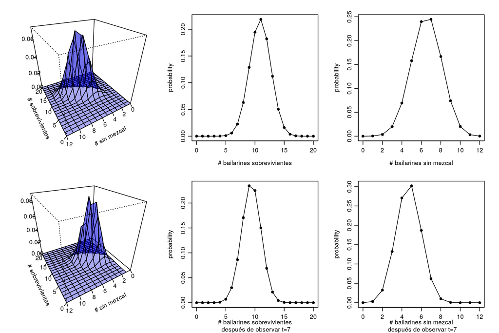

```r
# Computando las distribuciones posteriores marginales:
pos_f_g_t7 <- apply(posterior_fs_given_t7,
                     MARGIN = 1,FUN = sum,na.rm=T)
pos_s_g_t7 <- apply(posterior_fs_given_t7,
                     MARGIN = 2,FUN = sum,na.rm=T)

# Plotting
layout(matrix(1:6,ncol=3,byrow=T))
par(mgp=c(2.5,.75,0),mar=c(3.5,3.5,2,2))
# Primer reglón de la gráfica contiene los priors:
plot_joint_fs(sup_f,sup_s,p_fs,color='#0000dd55')
plot_marginal(sup_f,p_f,'# bailarines sobrevivientes')
plot_marginal(sup_s,p_s,'# bailarines sin mezcal')
# Segundo renglón presenta las distribuciones posteriores:
plot_joint_fs(sup_f,sup_s,posterior_fs_given_t7,color='#0000dd55')
plot_marginal(sup_f,pos_f_g_t7,'# bailarines sobrevivientes\n después de observar t=7')
plot_marginal(sup_s,pos_s_g_t7,'# bailarines sin mezcal\n después de observar t=7')
```

*En este caso, la observación `t=7` también es poco probable a priori, pero en el sentido contrario respecto a la observación `b=14`: observar un bailarín hasta el séptimo participante es consistente con valores de `f` y de `s` pequeños: entre menos bailarines hayan sobrevivido a la primera eliminación, y entre menos se hayan salvado del mezcal, el número esperado de personas a las que tenemos que preguntar antes de observar a un bailarín aumenta. Como resultado, la distribución conjunta posterior sobre `f` y `s`, se mueve hacia valores pequeños de ambas variables.*

**Como ejercicio de reflexión final (o como ejercicio formal, idealmente), ¿qué concluirías sobre `f` y `s` si dos amigos te dicen que fueron a la misma fiesta, en donde uno observa el resultado del primer ejercicio, `b=14`, y el otro el resultado del segundo, `t=7`? ¿Es posible que ocurra dicho escenario? ¿Cómo integrarías la información de ambos amigos para llegar a una sola conclusión sobre las combinaciones entre `f` y `s` más probables?**